# If you're opening this kernel for the first time, make sure to enable connection on your kernel and run the cell below (uncomment the 2nd and the 3rd lines)

### Above, we can see men who are between 20 to 40 are survived more compared to older aged men. But for the women odds don't depend on their age.

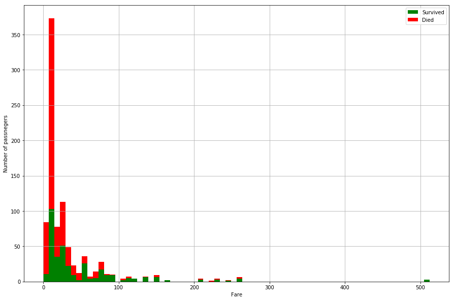

```python
plt.figure(figsize=(15,10))
plt.hist([train_data[train_data['Survived'] == 1]['Fare'], train_data[train_data['Died'] == 1]['Fare']],
        stacked=True, color=['g','r'], bins=70, label = ['Survived','Died'])
plt.xlabel('Fare')
plt.ylabel('Number of passnegers')
plt.legend()
plt.grid()
```

### we can see that the passengers with cheaper ticket fares are more likely to die

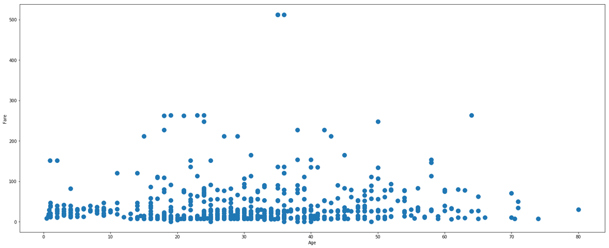

```python
plt.figure(figsize=(25,10))
ax=plt.subplot()
ax.scatter(train_data['Age'], train_data['Fare'], s=100)
plt.xlabel('Age')
plt.ylabel('Fare');
```

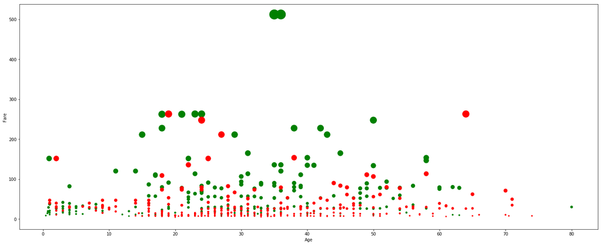

```python
plt.figure(figsize=(25,10))
ax=plt.subplot()

ax.scatter(train_data[train_data['Survived'] == 1]['Age'], train_data[train_data['Survived'] == 1]['Fare'],
          c='green', s=train_data[train_data['Survived'] == 1]['Fare'])
ax.scatter(train_data[train_data['Died'] == 1]['Age'], train_data[train_data['Died'] == 1]['Fare'],
          c='red', s=train_data[train_data['Died'] == 1]['Fare']);
plt.xlabel('Age')
plt.ylabel('Fare');
```

### Small green dots between x=0 & x=10 : Children who were survived.

### Small red dots between x=10 & x=45: Adults who died (from a lower classes).

### Large green dots between x=20 & x=45 : Adults with larger ticket fares who are survived.

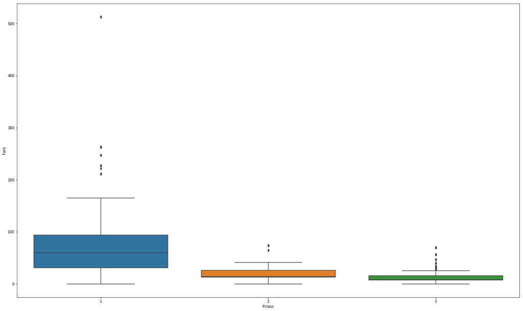

```python
plt.figure(figsize=(25,15))
sns.boxplot(x=train_data.Pclass, y=train_data.Fare);
```

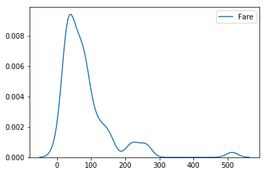

```python
sns.kdeplot(train_data[train_data.Pclass==1]['Fare']);
```

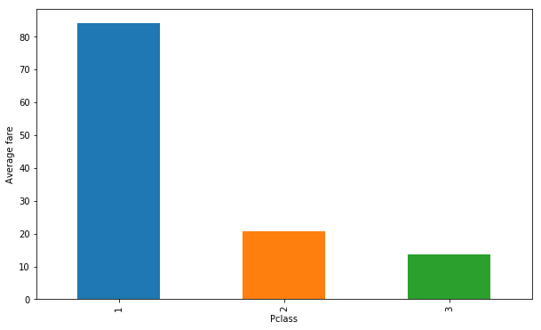

```python
ax=plt.subplot()
ax.set_ylabel('Average fare')
train_data.groupby('Pclass').mean()['Fare'].plot(kind='bar', ax=ax, figsize=(10,6) );
#the line above is the same as :
#train_data.groupby('Pclass').agg({'Fare':'mean'}).plot(kind='bar', ax=ax)
```

### Feature Engineering

# First rule !!!! _COMBINE THE TRAIN AND THE TEST SET TO APPLY THE SAME CHANGES ON BOTH.

```python
X_train = train_data.drop(['Survived','Died'],axis=1)
y_train = train_data['Survived']
X_test = pd.read_csv(path+'/test.csv')
full_data = pd.concat([X_train,X_test], ignore_index=True)
# otherwise : full_data=X_train.append(X_test)
print(X_train.shape[1])
print(full_data.shape[1])
```

```
11
11
```

### Processing Family column :

```python
def process_family(df):
    # introducing a new feature : the size of families (including the passenger)
    df['FamilySize'] = df['Parch'] + df['SibSp'] + 1

    # introducing other features based on the family size
    df['Singleton'] = df['FamilySize'].map(lambda s: 1 if s == 1 else 0)
    df['SmallFamily'] = df['FamilySize'].map(lambda s: 1 if 2 <= s <= 4 else 0)
    df['LargeFamily'] = df['FamilySize'].map(lambda s: 1 if 5 <= s else 0)
    df.drop(['FamilySize', 'Parch', 'SibSp'], axis=1, inplace=True)
    return df
```

```python
full_data = process_family(full_data)
full_data.head()
```

|  | PassengerId | Pclass | Name | Sex | Age | Ticket | Fare | Cabin | Embarked | Singleton | SmallFamily | LargeFamily |
| --- | --- | --- | --- | --- | --- | --- | --- | --- | --- | --- | --- | --- |
| 0 | 1 | 3 | Braund, Mr. Owen Harris | male | 22.0 | A/5 21171 | 7.2500 | NaN | S | 0 | 1 | 0 |
| 1 | 2 | 1 | Cumings, Mrs. John Bradley (Florence Briggs Th... | female | 38.0 | PC 17599 | 71.2833 | C85 | C | 0 | 1 | 0 |
| 2 | 3 | 3 | Heikkinen, Miss. Laina | female | 26.0 | STON/O2. 3101282 | 7.9250 | NaN | S | 1 | 0 | 0 |
| 3 | 4 | 1 | Futrelle, Mrs. Jacques Heath (Lily May Peel) | female | 35.0 | 113803 | 53.1000 | C123 | S | 0 | 1 | 0 |
| 4 | 5 | 3 | Allen, Mr. William Henry | male | 35.0 | 373450 | 8.0500 | NaN | S | 1 | 0 | 0 |

### Processing Embarked :

```python
print(full_data.Embarked.describe())
print('we have',full_data.Embarked.isna().sum(),'missing values in Emabrked column, which they are :')
full_data.loc[full_data.Embarked.isna()]
```

```
count     1307
unique       3
top          S
freq       914
Name: Embarked, dtype: object
we have 2 missing values in Emabrked column, which they are :
```

|  | PassengerId | Pclass | Name | Sex | Age | Ticket | Fare | Cabin | Embarked | Singleton | SmallFamily | LargeFamily |
| --- | --- | --- | --- | --- | --- | --- | --- | --- | --- | --- | --- | --- |
| 61 | 62 | 1 | Icard, Miss. Amelie | female | 38.0 | 113572 | 80.0 | B28 | NaN | 1 | 0 | 0 |
| 829 | 830 | 1 | Stone, Mrs. George Nelson (Martha Evelyn) | female | 62.0 | 113572 | 80.0 | B28 | NaN | 1 | 0 | 0 |

```python
full_data[(full_data.Pclass==1) & (full_data.Sex=='female')]['Embarked'].describe()
```

```
count     142
unique      3
top         C
freq       71
Name: Embarked, dtype: object
```

```python
def process_embarked(df):
    # two missing embarked values - filling them with the most frequent one in the train  set(S)
    df.Embarked.fillna('C', inplace=True)
    # dummy encoding
    df_dummies = pd.get_dummies(df['Embarked'], prefix='Embarked')
    df = pd.concat([df, df_dummies], axis=1)
    df.drop('Embarked', axis=1, inplace=True)
#     status('embarked')
    return df
```

```python
full_data = process_embarked(full_data)
full_data.head()
```

|  | PassengerId | Pclass | Name | Sex | Age | Ticket | Fare | Cabin | Singleton | SmallFamily | LargeFamily | Embarked_C | Embarked_Q | Embarked_S |
| --- | --- | --- | --- | --- | --- | --- | --- | --- | --- | --- | --- | --- | --- | --- |
| 0 | 1 | 3 | Braund, Mr. Owen Harris | male | 22.0 | A/5 21171 | 7.2500 | NaN | 0 | 1 | 0 | 0 | 0 | 1 |
| 1 | 2 | 1 | Cumings, Mrs. John Bradley (Florence Briggs Th... | female | 38.0 | PC 17599 | 71.2833 | C85 | 0 | 1 | 0 | 1 | 0 | 0 |
| 2 | 3 | 3 | Heikkinen, Miss. Laina | female | 26.0 | STON/O2. 3101282 | 7.9250 | NaN | 1 | 0 | 0 | 0 | 0 | 1 |
| 3 | 4 | 1 | Futrelle, Mrs. Jacques Heath (Lily May Peel) | female | 35.0 | 113803 | 53.1000 | C123 | 0 | 1 | 0 | 0 | 0 | 1 |
| 4 | 5 | 3 | Allen, Mr. William Henry | male | 35.0 | 373450 | 8.0500 | NaN | 1 | 0 | 0 | 0 | 0 | 1 |

### Processing Cabin

```python
print('we have',full_data.Cabin.isna().sum(),'missing value in Cabin column.')
full_data.Cabin.describe()
```

```
we have 1014 missing value in Cabin column.
```

```
count             295
unique            186
top       C23 C25 C27
freq                6
Name: Cabin, dtype: object
```

```python
from sklearn.preprocessing import LabelEncoder
```

```python
def process_cabin(df):
    # replacing missing cabins with U (for Uknown)
    df.Cabin.fillna('U', inplace=True)

    # mapping each Cabin value with the cabin letter
    df['Cabin'] = df['Cabin'].apply(lambda x: x[0])

    #Label Encoding ...
    df['Cabin']= LabelEncoder().fit_transform(df['Cabin'])

    # dummy encoding ...
    #cabin_dummies = pd.get_dummies(df['Cabin'], prefix='Cabin')
    #df = pd.concat([df, cabin_dummies], axis=1)

    #df.drop('Cabin', axis=1, inplace=True)
    return df
```

```python
full_data = process_cabin(full_data)
full_data.head(3)
```

|  | PassengerId | Pclass | Name | Sex | Age | Ticket | Fare | Cabin | Singleton | SmallFamily | LargeFamily | Embarked_C | Embarked_Q | Embarked_S |
| --- | --- | --- | --- | --- | --- | --- | --- | --- | --- | --- | --- | --- | --- | --- |
| 0 | 1 | 3 | Braund, Mr. Owen Harris | male | 22.0 | A/5 21171 | 7.2500 | 8 | 0 | 1 | 0 | 0 | 0 | 1 |
| 1 | 2 | 1 | Cumings, Mrs. John Bradley (Florence Briggs Th... | female | 38.0 | PC 17599 | 71.2833 | 2 | 0 | 1 | 0 | 1 | 0 | 0 |
| 2 | 3 | 3 | Heikkinen, Miss. Laina | female | 26.0 | STON/O2. 3101282 | 7.9250 | 8 | 1 | 0 | 0 | 0 | 0 | 1 |

## Preprocessing Name

#### Let's explore how many title we have :

```python
titles = set()
for name in full_data['Name']:
    titles.add(name.split(',')[1].split('.')[0].strip())
titles
```

```
{'Capt',
 'Col',
 'Don',
 'Dona',
 'Dr',
 'Jonkheer',
 'Lady',
 'Major',
 'Master',
 'Miss',
 'Mlle',
 'Mme',
 'Mr',
 'Mrs',
 'Ms',
 'Rev',
 'Sir',
 'the Countess'}
```

```python
def process_title (df):
    df['Title'] = df['Name'].apply(lambda x:x.split(',')[1].split('.')[0].strip())
    Title_Dict = {}
    Title_Dict.update(dict.fromkeys(['Capt', 'Col', 'Major', 'Dr', 'Rev'], 'Officer'))
    Title_Dict.update(dict.fromkeys(['Don', 'Sir', 'the Countess', 'Dona', 'Lady'], 'Royalty'))
    Title_Dict.update(dict.fromkeys(['Mme', 'Ms', 'Mrs'], 'Mrs'))
    Title_Dict.update(dict.fromkeys(['Mlle', 'Miss'], 'Miss'))
    Title_Dict.update(dict.fromkeys(['Mr'], 'Mr'))
    Title_Dict.update(dict.fromkeys(['Master','Jonkheer'], 'Master'))
    df['Title'] = df['Title'].map(Title_Dict)
    df.drop(['Name'], axis=1, inplace=True)
    return df
```

```python
full_data = process_title(full_data)
full_data.head(3)
```

|  | PassengerId | Pclass | Sex | Age | Ticket | Fare | Cabin | Singleton | SmallFamily | LargeFamily | Embarked_C | Embarked_Q | Embarked_S | Title |
| --- | --- | --- | --- | --- | --- | --- | --- | --- | --- | --- | --- | --- | --- | --- |
| 0 | 1 | 3 | male | 22.0 | A/5 21171 | 7.2500 | 8 | 0 | 1 | 0 | 0 | 0 | 1 | Mr |
| 1 | 2 | 1 | female | 38.0 | PC 17599 | 71.2833 | 2 | 0 | 1 | 0 | 1 | 0 | 0 | Mrs |
| 2 | 3 | 3 | female | 26.0 | STON/O2. 3101282 | 7.9250 | 8 | 1 | 0 | 0 | 0 | 0 | 1 | Miss |

```python
# Title_Dictionary = {
#      'Capt':'Officier',
#      'Col':'Officier',
#      'Don':'Royalty',
#      'Dona':'Royalty',
#      'Dr':'Officier',
#      'Jonkheer':'Royalty',
#      'Lady':'Royalty',
#      'Major':'Officier',
#      'Master':'Master',
#      'Miss':'Miss',
#      'Mlle':'Miss',
#      'Mme':'Mrs',
#      'Mr':'Mr',
#      'Mrs':'Mrs',
#      'Ms':'Mrs',
#      'Rev':'Officier',
#      'Sir':'Royalty',
#      'the Countess':'Royalty'
# }
# def passenger_title(df):
#     df['Title'] = df['Name'].apply(lambda x:x.split(',')[1].split('.')[0].strip())
#     df['Title'] = df['Title'].apply( lambda x : Title_Dictionary[x])
#     df.drop(['Name'], axis=1, inplace=True)
#     return df
```

```python
# full_data = passenger_title(full_data)
# full_data.head()
```

## Preprocessing Age

#### In the training session we processed the Age as below, but this time I will use an imputatuin method which is regressor :

#### the commented cells contain the approach we've used in the training session:

```python
# grouped_median_train = full_data.groupby(['Sex','Pclass','Title']).agg({'Age':'median'}).reset_index()
# grouped_median_train.head()
```

```python
#Adding the value of age for missing values based on the grouped_median_train
```

```python
# def fill_age(row):
#     condition = (
#         (grouped_median_train['Sex'] == row['Sex']) &
#         (grouped_median_train['Title'] == row['Title']) &
#         (grouped_median_train['Pclass'] == row['Pclass'])
#     )
#     return grouped_median_train[condition]['Age'].values[0]

# def process_age(df):
#     # a function that fills the missing values of the Age variable
#     df['Age'] = df.apply(lambda row: fill_age(row) if np.isnan(row['Age']) else row['Age'], axis=1)
#     return df
```

```python
# full_data = process_age(full_data)
# full_data.head()
```

### Using the regressor :

#### we will use Pclass, Sex and Title colmuns to predict the missing age :

```python
from sklearn.ensemble import RandomForestRegressor
age_df = full_data[['Age', 'Pclass','Sex','Title']]
age_df = pd.get_dummies(age_df)
age_df.head(3)
```

|  | Age | Pclass | Sex_female | Sex_male | Title_Master | Title_Miss | Title_Mr | Title_Mrs | Title_Officer | Title_Royalty |
| --- | --- | --- | --- | --- | --- | --- | --- | --- | --- | --- |
| 0 | 22.0 | 3 | 0 | 1 | 0 | 0 | 1 | 0 | 0 | 0 |
| 1 | 38.0 | 1 | 1 | 0 | 0 | 0 | 0 | 1 | 0 | 0 |
| 2 | 26.0 | 3 | 1 | 0 | 0 | 1 | 0 | 0 | 0 | 0 |

```python
known_age_df = age_df[age_df.Age.notna()]
unknown_age_df = age_df[age_df.Age.isna()]
print(known_age_df.head(3))
unknown_age_df.head(3)
```

```
    Age  Pclass  Sex_female  Sex_male  Title_Master  Title_Miss  Title_Mr  \
0  22.0       3           0         1             0           0         1
1  38.0       1           1         0             0           0         0
2  26.0       3           1         0             0           1         0

   Title_Mrs  Title_Officer  Title_Royalty
0          0              0              0
1          1              0              0
2          0              0              0
```

|  | Age | Pclass | Sex_female | Sex_male | Title_Master | Title_Miss | Title_Mr | Title_Mrs | Title_Officer | Title_Royalty |
| --- | --- | --- | --- | --- | --- | --- | --- | --- | --- | --- |
| 5 | NaN | 3 | 0 | 1 | 0 | 0 | 1 | 0 | 0 | 0 |
| 17 | NaN | 2 | 0 | 1 | 0 | 0 | 1 | 0 | 0 | 0 |
| 19 | NaN | 3 | 1 | 0 | 0 | 0 | 0 | 1 | 0 | 0 |

```python
X = known_age_df.drop(['Age'], axis=1)
y = known_age_df['Age']
```

```python
rfr = RandomForestRegressor(random_state=0, n_estimators=100, n_jobs=-1)
rfr.fit(X, y)
```

```
RandomForestRegressor(bootstrap=True, criterion='mse', max_depth=None,
           max_features='auto', max_leaf_nodes=None,
           min_impurity_decrease=0.0, min_impurity_split=None,
           min_samples_leaf=1, min_samples_split=2,
           min_weight_fraction_leaf=0.0, n_estimators=100, n_jobs=-1,
           oob_score=False, random_state=0, verbose=0, warm_start=False)
```

```python
predicted_ages = rfr.predict(unknown_age_df.drop(['Age'], axis=1))
```

```python
full_data.loc[full_data.Age.isna(), 'Age']= predicted_ages
```

```python
full_data.Age.isna().sum()
```

```
0
```

```python
full_data.isna().sum()
```

```
PassengerId    0
Pclass         0
Sex            0
Age            0
Ticket         0
Fare           1
Cabin          0
Singleton      0
SmallFamily    0
LargeFamily    0
Embarked_C     0
Embarked_Q     0
Embarked_S     0
Title          0
dtype: int64
```

### we still have one missing value in the Fare column, so let's fix it :

```python
full_data[full_data.Fare.isna()]
```

|  | PassengerId | Pclass | Sex | Age | Ticket | Fare | Cabin | Singleton | SmallFamily | LargeFamily | Embarked_C | Embarked_Q | Embarked_S | Title |
| --- | --- | --- | --- | --- | --- | --- | --- | --- | --- | --- | --- | --- | --- | --- |
| 1043 | 1044 | 3 | male | 60.5 | 3701 | NaN | 8 | 1 | 0 | 0 | 0 | 0 | 1 | Mr |

```python
full_data[(full_data.Pclass == 3) & (full_data.Sex == 'male') & (full_data.Singleton==1) & (full_data.Cabin == 8)].Fare.describe()
```

```
count    363.000000
mean       9.286119
std        7.517326
min        0.000000
25%        7.577100
50%        7.895800
75%        8.050000
max       56.495800
Name: Fare, dtype: float64
```

```python
full_data['Fare'].fillna(full_data[(full_data.Pclass == 3) & (full_data.Sex == 'male') & (full_data.Singleton==1) & (full_data.Cabin == 8)].Fare.mean(), inplace= True)
```

```python
full_data.isna().sum()
```

```
PassengerId    0
Pclass         0
Sex            0
Age            0
Ticket         0
Fare           0
Cabin          0
Singleton      0
SmallFamily    0
LargeFamily    0
Embarked_C     0
Embarked_Q     0
Embarked_S     0
Title          0
dtype: int64
```

# Now let's encode the data :

## Encoding Title :

```python
full_data['Title'].describe()
```

```
count     1309
unique       6
top         Mr
freq       757
Name: Title, dtype: object
```

```python
def encode_title(df):
    #dummification Title column
    titles_dummies = pd.get_dummies(df['Title'], prefix='Title')
    df = pd.concat([df, titles_dummies], axis=1)
    #removing the title column since we have its dummies
    df.drop('Title', axis=1, inplace=True)

    #lebel Encoding Title column:
#   df['Title'] = LabelEncoder().fit_transform(df['Title'])
    return df
```

```python
full_data = encode_title(full_data)
full_data.head()
```

|  | PassengerId | Pclass | Sex | Age | Ticket | Fare | Cabin | Singleton | SmallFamily | LargeFamily | Embarked_C | Embarked_Q | Embarked_S | Title_Master | Title_Miss | Title_Mr | Title_Mrs | Title_Officer | Title_Royalty |
| --- | --- | --- | --- | --- | --- | --- | --- | --- | --- | --- | --- | --- | --- | --- | --- | --- | --- | --- | --- |
| 0 | 1 | 3 | male | 22.0 | A/5 21171 | 7.2500 | 8 | 0 | 1 | 0 | 0 | 0 | 1 | 0 | 0 | 1 | 0 | 0 | 0 |
| 1 | 2 | 1 | female | 38.0 | PC 17599 | 71.2833 | 2 | 0 | 1 | 0 | 1 | 0 | 0 | 0 | 0 | 0 | 1 | 0 | 0 |
| 2 | 3 | 3 | female | 26.0 | STON/O2. 3101282 | 7.9250 | 8 | 1 | 0 | 0 | 0 | 0 | 1 | 0 | 1 | 0 | 0 | 0 | 0 |
| 3 | 4 | 1 | female | 35.0 | 113803 | 53.1000 | 2 | 0 | 1 | 0 | 0 | 0 | 1 | 0 | 0 | 0 | 1 | 0 | 0 |
| 4 | 5 | 3 | male | 35.0 | 373450 | 8.0500 | 8 | 1 | 0 | 0 | 0 | 0 | 1 | 0 | 0 | 1 | 0 | 0 | 0 |

## Encoding Sex :

```python
def encode_sex(df):
    #dummification Sex column
    Sex_dummies = pd.get_dummies(df['Sex'])
    df = pd.concat([df, Sex_dummies], axis=1)

    #removing the Sex column since we have its dummies
    df.drop('Sex', axis=1, inplace=True)
    return df
```

```python
full_data = encode_sex(full_data)
full_data.head()
```

|  | PassengerId | Pclass | Age | Ticket | Fare | Cabin | Singleton | SmallFamily | LargeFamily | Embarked_C | Embarked_Q | Embarked_S | Title_Master | Title_Miss | Title_Mr | Title_Mrs | Title_Officer | Title_Royalty | female | male |
| --- | --- | --- | --- | --- | --- | --- | --- | --- | --- | --- | --- | --- | --- | --- | --- | --- | --- | --- | --- | --- |
| 0 | 1 | 3 | 22.0 | A/5 21171 | 7.2500 | 8 | 0 | 1 | 0 | 0 | 0 | 1 | 0 | 0 | 1 | 0 | 0 | 0 | 0 | 1 |
| 1 | 2 | 1 | 38.0 | PC 17599 | 71.2833 | 2 | 0 | 1 | 0 | 1 | 0 | 0 | 0 | 0 | 0 | 1 | 0 | 0 | 1 | 0 |
| 2 | 3 | 3 | 26.0 | STON/O2. 3101282 | 7.9250 | 8 | 1 | 0 | 0 | 0 | 0 | 1 | 0 | 1 | 0 | 0 | 0 | 0 | 1 | 0 |
| 3 | 4 | 1 | 35.0 | 113803 | 53.1000 | 2 | 0 | 1 | 0 | 0 | 0 | 1 | 0 | 0 | 0 | 1 | 0 | 0 | 1 | 0 |
| 4 | 5 | 3 | 35.0 | 373450 | 8.0500 | 8 | 1 | 0 | 0 | 0 | 0 | 1 | 0 | 0 | 1 | 0 | 0 | 0 | 0 | 1 |

## Encoding ticket :

```python
full_data.Ticket.describe()
```

```
count         1309
unique         929
top       CA. 2343
freq            11
Name: Ticket, dtype: object
```

```python
Ticket_count = dict(full_data['Ticket'].value_counts())
full_data['Ticket_Count_Group'] = full_data['Ticket'].apply(lambda x : Ticket_count[x])
full_data.drop(['Ticket'], axis=1, inplace=True)
full_data.head()
```

|  | PassengerId | Pclass | Age | Fare | Cabin | Singleton | SmallFamily | LargeFamily | Embarked_C | Embarked_Q | Embarked_S | Title_Master | Title_Miss | Title_Mr | Title_Mrs | Title_Officer | Title_Royalty | female | male | Ticket_Count_Group |
| --- | --- | --- | --- | --- | --- | --- | --- | --- | --- | --- | --- | --- | --- | --- | --- | --- | --- | --- | --- | --- |
| 0 | 1 | 3 | 22.0 | 7.2500 | 8 | 0 | 1 | 0 | 0 | 0 | 1 | 0 | 0 | 1 | 0 | 0 | 0 | 0 | 1 | 1 |
| 1 | 2 | 1 | 38.0 | 71.2833 | 2 | 0 | 1 | 0 | 1 | 0 | 0 | 0 | 0 | 0 | 1 | 0 | 0 | 1 | 0 | 2 |
| 2 | 3 | 3 | 26.0 | 7.9250 | 8 | 1 | 0 | 0 | 0 | 0 | 1 | 0 | 1 | 0 | 0 | 0 | 0 | 1 | 0 | 1 |
| 3 | 4 | 1 | 35.0 | 53.1000 | 2 | 0 | 1 | 0 | 0 | 0 | 1 | 0 | 0 | 0 | 1 | 0 | 0 | 1 | 0 | 2 |
| 4 | 5 | 3 | 35.0 | 8.0500 | 8 | 1 | 0 | 0 | 0 | 0 | 1 | 0 | 0 | 1 | 0 | 0 | 0 | 0 | 1 | 1 |

```python
full_data.Ticket_Count_Group.unique().size
```

```
9
```

### so we have only 9 unique value in the Ticket_Count_Group column. And guess what !!! its type is int (already encoded ;) )

```python
enc = LabelEncoder()
full_data['Ticket_Count_Group'] = enc.fit_transform(full_data['Ticket_Count_Group'])
full_data.head()
```

|  | PassengerId | Pclass | Age | Fare | Cabin | Singleton | SmallFamily | LargeFamily | Embarked_C | Embarked_Q | Embarked_S | Title_Master | Title_Miss | Title_Mr | Title_Mrs | Title_Officer | Title_Royalty | female | male | Ticket_Count_Group |
| --- | --- | --- | --- | --- | --- | --- | --- | --- | --- | --- | --- | --- | --- | --- | --- | --- | --- | --- | --- | --- |
| 0 | 1 | 3 | 22.0 | 7.2500 | 8 | 0 | 1 | 0 | 0 | 0 | 1 | 0 | 0 | 1 | 0 | 0 | 0 | 0 | 1 | 0 |
| 1 | 2 | 1 | 38.0 | 71.2833 | 2 | 0 | 1 | 0 | 1 | 0 | 0 | 0 | 0 | 0 | 1 | 0 | 0 | 1 | 0 | 1 |
| 2 | 3 | 3 | 26.0 | 7.9250 | 8 | 1 | 0 | 0 | 0 | 0 | 1 | 0 | 1 | 0 | 0 | 0 | 0 | 1 | 0 | 0 |
| 3 | 4 | 1 | 35.0 | 53.1000 | 2 | 0 | 1 | 0 | 0 | 0 | 1 | 0 | 0 | 0 | 1 | 0 | 0 | 1 | 0 | 1 |
| 4 | 5 | 3 | 35.0 | 8.0500 | 8 | 1 | 0 | 0 | 0 | 0 | 1 | 0 | 0 | 1 | 0 | 0 | 0 | 0 | 1 | 0 |

```python
print('the size of the train set is',train_data.shape)
```

```
the size of the train set is (891, 13)
```

```python
train_data = pd.concat([full_data[:891], train_data['Survived']], axis=1)
```

```python
train_data.head(10)
```

|  | PassengerId | Pclass | Age | Fare | Cabin | Singleton | SmallFamily | LargeFamily | Embarked_C | Embarked_Q | ... | Title_Master | Title_Miss | Title_Mr | Title_Mrs | Title_Officer | Title_Royalty | female | male | Ticket_Count_Group | Survived |
| --- | --- | --- | --- | --- | --- | --- | --- | --- | --- | --- | --- | --- | --- | --- | --- | --- | --- | --- | --- | --- | --- |
| 0 | 1 | 3 | 22.000000 | 7.2500 | 8 | 0 | 1 | 0 | 0 | 0 | ... | 0 | 0 | 1 | 0 | 0 | 0 | 0 | 1 | 0 | 0 |
| 1 | 2 | 1 | 38.000000 | 71.2833 | 2 | 0 | 1 | 0 | 1 | 0 | ... | 0 | 0 | 0 | 1 | 0 | 0 | 1 | 0 | 1 | 1 |
| 2 | 3 | 3 | 26.000000 | 7.9250 | 8 | 1 | 0 | 0 | 0 | 0 | ... | 0 | 1 | 0 | 0 | 0 | 0 | 1 | 0 | 0 | 1 |
| 3 | 4 | 1 | 35.000000 | 53.1000 | 2 | 0 | 1 | 0 | 0 | 0 | ... | 0 | 0 | 0 | 1 | 0 | 0 | 1 | 0 | 1 | 1 |
| 4 | 5 | 3 | 35.000000 | 8.0500 | 8 | 1 | 0 | 0 | 0 | 0 | ... | 0 | 0 | 1 | 0 | 0 | 0 | 0 | 1 | 0 | 0 |
| 5 | 6 | 3 | 28.226256 | 8.4583 | 8 | 1 | 0 | 0 | 0 | 1 | ... | 0 | 0 | 1 | 0 | 0 | 0 | 0 | 1 | 0 | 0 |
| 6 | 7 | 1 | 54.000000 | 51.8625 | 4 | 1 | 0 | 0 | 0 | 0 | ... | 0 | 0 | 1 | 0 | 0 | 0 | 0 | 1 | 1 | 0 |
| 7 | 8 | 3 | 2.000000 | 21.0750 | 8 | 0 | 0 | 1 | 0 | 0 | ... | 1 | 0 | 0 | 0 | 0 | 0 | 0 | 1 | 4 | 0 |
| 8 | 9 | 3 | 27.000000 | 11.1333 | 8 | 0 | 1 | 0 | 0 | 0 | ... | 0 | 0 | 0 | 1 | 0 | 0 | 1 | 0 | 2 | 1 |
| 9 | 10 | 2 | 14.000000 | 30.0708 | 8 | 0 | 1 | 0 | 1 | 0 | ... | 0 | 0 | 0 | 1 | 0 | 0 | 1 | 0 | 1 | 1 |

10 rows × 21 columns

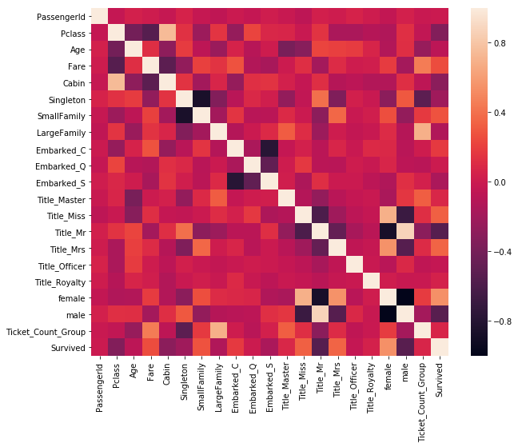

```python
plt.figure(figsize=(10,8))
sns.heatmap(train_data.corr());
```

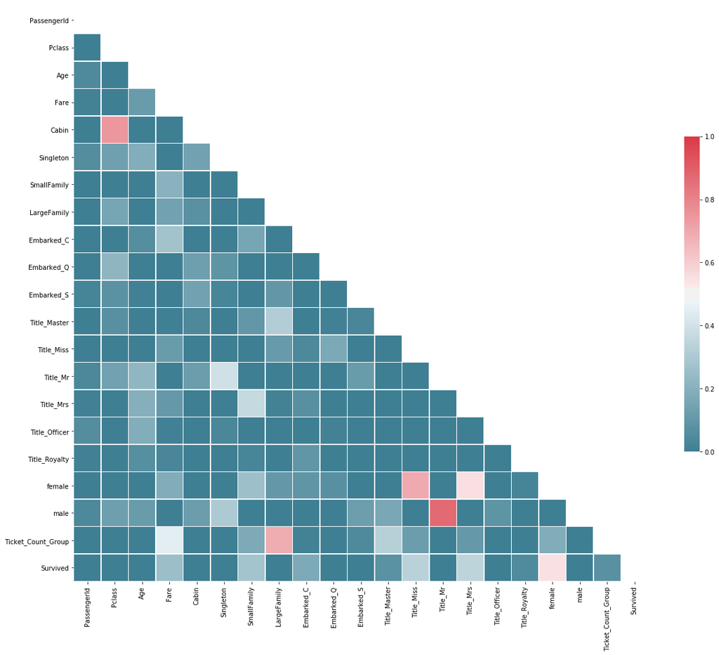

```python
plt.figure(figsize=(20,18))
corr_matrix = train_data.corr()
mask = np.zeros_like(corr_matrix, dtype=np.bool)
mask[np.triu_indices_from(mask)] = True
cmap = sns.diverging_palette(220, 10, as_cmap=True)
sns.heatmap(corr_matrix, mask=mask,cmap=cmap, vmax=1 , vmin=0, center=0.5,
            square=True, linewidths=.5, cbar_kws={"shrink": .5});
```

### Building and training the model

```python
X_train = full_data[:891]
X_test = full_data[891:]
print(X_train.shape)
print(X_test.shape)
```

```
(891, 20)
(418, 20)
```

#### Splitting the train set into train and dev set

```python
def split_vals(df,num_sample_to_train): return df[:num_sample_to_train], df[num_sample_to_train:]
valid_count =60
n_trn = len(X_train)-valid_count
X_train1, X_valid1 = split_vals(X_train, n_trn)
y_train1, y_valid1 = split_vals(y_train, n_trn)
```

```python
X_train1.shape,y_train1.shape,X_valid1.shape,y_valid1.shape
```

```
((831, 20), (831,), (60, 20), (60,))
```

```python
from sklearn import metrics
from sklearn.ensemble import RandomForestClassifier
from sklearn.model_selection import GridSearchCV

rfc = RandomForestClassifier(n_estimators=180,
                             min_samples_leaf=3,
                             max_features=0.5,
                             n_jobs=-1)
rfc.fit(X_train1,y_train1)
rfc.score(X_train1,y_train1)
```

```
0.9181708784596871
```

```python
y_predict=rfc.predict(X_valid1)
metrics.accuracy_score(y_valid1,y_predict)
```

```
0.8833333333333333
```

```python
print(metrics.classification_report(y_valid1,y_predict))
```

```
              precision    recall  f1-score   support

           0       0.90      0.92      0.91        38
           1       0.86      0.82      0.84        22

   micro avg       0.88      0.88      0.88        60
   macro avg       0.88      0.87      0.87        60
weighted avg       0.88      0.88      0.88        60
```

# confusion matrix

[figure not shown]

```python
print(metrics.confusion_matrix(y_valid1,y_predict))
```

```
[[35  3]
 [ 4 18]]
```

### Feature importance

```python
from fastai.imports import *
from fastai.structured import *
from pandas_summary import DataFrameSummary
from sklearn.ensemble import RandomForestRegressor, RandomForestClassifier,GradientBoostingClassifier
from IPython.display import display
from sklearn import metrics
from sklearn.model_selection import StratifiedKFold
from sklearn.model_selection import GridSearchCV
import seaborn as sns
import pylab as plot
```

```python
fi = rf_feat_importance(rfc, X_train1);
fi
```

|  | cols | imp |
| --- | --- | --- |
| 13 | Title_Mr | 0.154394 |
| 0 | PassengerId | 0.121803 |
| 17 | female | 0.117744 |
| 3 | Fare | 0.114829 |
| 18 | male | 0.109827 |
| 2 | Age | 0.107483 |
| 1 | Pclass | 0.076794 |
| 19 | Ticket_Count_Group | 0.052136 |
| 4 | Cabin | 0.040387 |
| 7 | LargeFamily | 0.030798 |
| 6 | SmallFamily | 0.015403 |
| 10 | Embarked_S | 0.009895 |
| 11 | Title_Master | 0.008761 |
| 15 | Title_Officer | 0.008126 |
| 8 | Embarked_C | 0.007007 |
| 14 | Title_Mrs | 0.006840 |
| 12 | Title_Miss | 0.006611 |
| 5 | Singleton | 0.006611 |
| 9 | Embarked_Q | 0.004514 |
| 16 | Title_Royalty | 0.000038 |

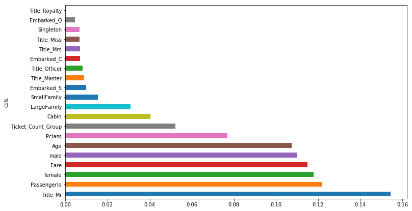

```python
def plot_fi(fi): return fi.plot('cols', 'imp', 'barh', figsize=(12,7), legend=False)
plot_fi(fi);
```

### Keeping only the variables which are significant for the model(>0.01)

```python
to_keep = fi[fi.imp>0.01].cols;
print(len(to_keep))
to_keep
```

```
11
```

```
13              Title_Mr
0            PassengerId
17                female
3                   Fare
18                  male
2                    Age
1                 Pclass
19    Ticket_Count_Group
4                  Cabin
7            LargeFamily
6            SmallFamily
Name: cols, dtype: object
```

# Now training the model on the entire data with only the important features.

```python
X_train = X_train[to_keep]
X_train.head()
```

|  | Title_Mr | PassengerId | female | Fare | male | Age | Pclass | Ticket_Count_Group | Cabin | LargeFamily | SmallFamily |
| --- | --- | --- | --- | --- | --- | --- | --- | --- | --- | --- | --- |
| 0 | 1 | 1 | 0 | 7.2500 | 1 | 22.0 | 3 | 0 | 8 | 0 | 1 |
| 1 | 0 | 2 | 1 | 71.2833 | 0 | 38.0 | 1 | 1 | 2 | 0 | 1 |
| 2 | 0 | 3 | 1 | 7.9250 | 0 | 26.0 | 3 | 0 | 8 | 0 | 0 |
| 3 | 0 | 4 | 1 | 53.1000 | 0 | 35.0 | 1 | 1 | 2 | 0 | 1 |
| 4 | 1 | 5 | 0 | 8.0500 | 1 | 35.0 | 3 | 0 | 8 | 0 | 0 |

```python
rfc = RandomForestClassifier(n_estimators=150,min_samples_leaf=3,max_features=0.5,n_jobs=-1)
rfc.fit(X_train,y_train)
rfc.score(X_train,y_train)
```

```
0.9169472502805837
```

```python
X_test = X_test[to_keep]
X_test.Fare.fillna(14, inplace=True)
output=rfc.predict(X_test)
```

```python
data_test = pd.read_csv(path+'/test.csv')
df_output = pd.DataFrame()
df_output['PassengerId'] = data_test['PassengerId']
df_output['Survived'] = output
df_output[['PassengerId','Survived']].to_csv('submission11.csv', index=False)
```

```python
df_output.head(10)
```

|  | PassengerId | Survived |
| --- | --- | --- |
| 0 | 892 | 0 |
| 1 | 893 | 0 |
| 2 | 894 | 0 |
| 3 | 895 | 0 |
| 4 | 896 | 0 |
| 5 | 897 | 0 |
| 6 | 898 | 1 |
| 7 | 899 | 0 |
| 8 | 900 | 1 |
| 9 | 901 | 0 |

# Guess what guys !!!! we're TOP 11%

[figure not shown]

## Trying another model

```python
X = X_train
y = train_data['Survived']
```

```python
from sklearn.pipeline import Pipeline
from sklearn.ensemble import RandomForestClassifier
from sklearn.model_selection import GridSearchCV
from sklearn.feature_selection import SelectKBest

pipe=Pipeline([('select',SelectKBest(k='all')),
               ('classify', RandomForestClassifier(random_state = 10, max_features = 'sqrt'))])

param_test = {'classify__n_estimators':list(range(20,50,2)),
              'classify__max_depth':list(range(3,60,3))}
gsearch = GridSearchCV(estimator = pipe, param_grid = param_test, scoring='roc_auc', cv=10)
gsearch.fit(X,y)
print(gsearch.best_params_, gsearch.best_score_)
```

```
{'classify__max_depth': 6, 'classify__n_estimators': 20} 0.8780573817346776
```

```python
from sklearn.pipeline import make_pipeline
select = SelectKBest(k = 'all')
clf = RandomForestClassifier(random_state = 10, warm_start = True,
                                  n_estimators = 26,
                                  max_depth = 6,
                                  max_features = 'sqrt')
pipeline = make_pipeline(select, clf)
pipeline.fit(X, y)
```

```
Pipeline(memory=None,
     steps=[('selectkbest', SelectKBest(k='all', score_func=<function f_classif at 0x7f4ac8548730>)), ('randomforestclassifier', RandomForestClassifier(bootstrap=True, class_weight=None, criterion='gini',
            max_depth=6, max_features='sqrt', max_leaf_nodes=None,
            min_impurity_decrease...imators=26, n_jobs=None,
            oob_score=False, random_state=10, verbose=0, warm_start=True))])
```

```python
from sklearn import metrics
from sklearn.model_selection import cross_val_score
cv_score = cross_val_score(pipeline, X, y, cv= 10)
print("CV Score : Mean - %.7g | Std - %.7g " % (np.mean(cv_score), np.std(cv_score)))
```

```
CV Score : Mean - 0.8304826 | Std - 0.02747618
```

```python
predictions = pipeline.predict(X_test)
submission = pd.DataFrame({"PassengerId": pd.read_csv(path+'test.csv')['PassengerId'], "Survived": predictions.astype(np.int32)})
submission.to_csv("submission11.csv", index=False)
submission.info()
```

```
<class 'pandas.core.frame.DataFrame'>
RangeIndex: 418 entries, 0 to 417
Data columns (total 2 columns):
PassengerId    418 non-null int64
Survived       418 non-null int32
dtypes: int32(1), int64(1)
memory usage: 5.0 KB
```